# Case Study 8

Haleigh Borich

10/26/2021

```r
library(qdapRegex)
library(tidyverse)
library(downloader)
library(readr)
library(stringi)
```

```r
bob1 <- tempfile()
download("https://raw.githubusercontent.com/WJC-Data-Science/DTS350/master/bible.csv", bob1, mode = "wb")
ScriptData <- read_csv(bob1)
head(ScriptData)
```

```
## # A tibble: 6 x 17
##   volume_id book_id chapter_id verse_id volume_title book_title volume_long_tit…
##       <dbl>   <dbl>      <dbl>    <dbl> <chr>        <chr>      <chr>
## 1         1       1          1        1 Old Testame… Genesis    The Old Testame…
## 2         1       1          1        2 Old Testame… Genesis    The Old Testame…
## 3         1       1          1        3 Old Testame… Genesis    The Old Testame…
## 4         1       1          1        4 Old Testame… Genesis    The Old Testame…
## 5         1       1          1        5 Old Testame… Genesis    The Old Testame…
## 6         1       1          1        6 Old Testame… Genesis    The Old Testame…
## # … with 10 more variables: book_long_title <chr>, volume_subtitle <lgl>,
## #   book_subtitle <lgl>, volume_short_title <chr>, book_short_title <chr>,
## #   chapter_number <dbl>, verse_number <dbl>, scripture_text <chr>,
## #   verse_title <chr>, verse_short_title <chr>
```

```r
bob2 <- tempfile()
download("https://raw.githubusercontent.com/WJC-Data-Science/DTS350/master/Names.csv", bob2, mode = "wb")
NameData <- read_csv(bob2)
head(NameData)
```

```
## # A tibble: 6 x 4
##      X1 name                                                         nchar words
##   <dbl> <chr>                                                        <dbl> <dbl>
## 1     1 the Father of the heavens and of the earth, and all things …    75    16
## 2     2 Creator of all things from the beginning                        40     7
## 3     3 Jesus Christ, the Son of the living God                         39     8
## 4     4 the Lord Jesus Christ, their Redeemer                           37     6
## 5     5 God of Abraham, and Isaac, and Jacob                            36     7
## 6     6 Eternal Father of heaven and earth                              34     6
```

```r
OldTest <- ScriptData %>%
  filter(volume_long_title == "The Old Testament") %>%
  select(scripture_text) %>%
  str_c()
NewTest <- ScriptData %>%
  filter(volume_long_title == "The New Testament") %>%
  select(scripture_text) %>%
  str_c()
Savior_Name <- NameData %>%
  select(name)
head(Savior_Name)
```

```
## # A tibble: 6 x 1
##   name
##   <chr>
## 1 the Father of the heavens and of the earth, and all things that in them are
## 2 Creator of all things from the beginning
## 3 Jesus Christ, the Son of the living God
## 4 the Lord Jesus Christ, their Redeemer
## 5 God of Abraham, and Isaac, and Jacob
## 6 Eternal Father of heaven and earth
```

```r
str_detect(OldTest, "abcxyz")
```

```
## [1] FALSE
```

```r
str_detect(NewTest, "abcxyz")
```

```
## [1] FALSE
```

Savior References Function

```r
Savior_Ref <- function(df) {
  count <- vector("integer", ncol(Savior_Name))
  for (name in Savior_Name) {
    count <- count + str_length(str_extract_all(df, name))
    names(count)
  }
  count
}
```

How many times Savior was mentioned in:

Old Testament

```r
sum(Savior_Ref(OldTest))
```

```
## [1] 33187
```

33,187

New Testament

```r
sum(Savior_Ref(NewTest))
```

```
## [1] 44280
```

44,280

Finding the words between each instances of a Savior reference

```r
Between_Words <- function(df, test) {
  for (names in Savior_Name$name) {
    Replace <- str_replace_all(df, names, "abcxyz")
  }
  Split_Words <- str_split(Replace, "abcxyz")
  Split_Words_N <- str_remove_all(Split_Words, "\n")
  if (test == "mean") {
    stri_stats_latex(unlist(Split_Words_N))[[4]]/length(unlist(Split_Words))
  } else {
    stri_stats_latex(unlist(Split_Words_N)) [[4]]
  }
}
```

How many words in between each instance:

Old Testament

```r
Between_Words(OldTest, "between")
```

```
## [1] 611503
```

611,503

New Testament

```r
Between_Words(NewTest, "between")
```

```
## [1] 180662
```

180,662

The average amount of words between each instance:

Old Testament

```r
Between_Words(OldTest, "mean")
```

```
## [1] 3135.913
```

3,135.913

New Testament

```r
Between_Words(NewTest, "mean")
```

```
## [1] 12044.13
```

12,044.13

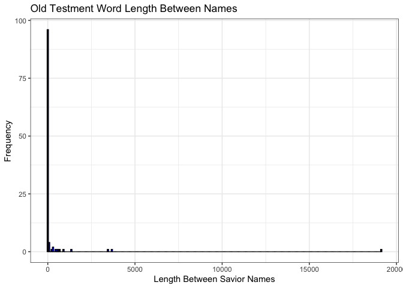

```r
as.data.frame(Savior_Ref(OldTest)) %>%
  ggplot(aes(x = Savior_Ref(OldTest))) +
    geom_histogram(color = "black", fill = "blue", binwidth = 75) +
    labs(x = "Length Between Savior Names", y = "Frequency", title = "Old Testment Word Length Between Names") +
    theme_bw()
```

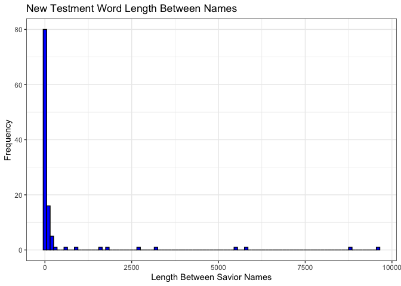

```r
as.data.frame(Savior_Ref(NewTest)) %>%
  ggplot(aes(x = Savior_Ref(NewTest))) +
    geom_histogram(color = "black",fill = "blue", binwidth = 100) +
    labs(x = "Length Between Savior Names", y = "Frequency", title = "New Testment Word Length Between Names") +
    theme_bw()
```

After doing extensive research, I was able to figure out that the New Testament has more references to a Savior name than the Old Testament does. The New Testament has a total of 44,280 references throughout the book while the Old Testament has a total of 33,187 mentioned of Savior references. Later on, I was able to find out that the Old Testament and the New Testament have varying lengths. I was able to conclude that from finding the average of length between each savior reference. The Old Testament has, on an average, 3,135 words in between each Savior reference, while the New Testament has, on an average, 12,044.13